# Modelling and Forecasting with SARIMA Models

Maria Eduarda Silva

LMU, July 1 2022

# Hands on

- Consider the time series you have already analised
- Plot the data. Does it look stationary?
- Calculate and plot ACF and PACF. Which model do these plots suggest?
- Fit such a model using sarima function.
- Comment on the significance of the parameter estimates
- Examine the residuals. Are they white noise?
- Repeat with an higher/lower order model.
- Split the data into train (80%) and test set (20%)
- Model the train set
- Obtain forecasts for the test set. Measure the accuracy of the forecasts.
- Summarize your findings in a table:

| Date | Observed | Forecast | MAPE | Lower | Upper | CI | Contains true |
| --- | --- | --- | --- | --- | --- | --- | --- |

# Modelling CARDOX

```r
library(fpp2)
library(astsa)
```

Monthly mean carbon dioxide (in ppm) measured at Mauna Loa Observatory, Hawaii. March, 1958 to November, 2018

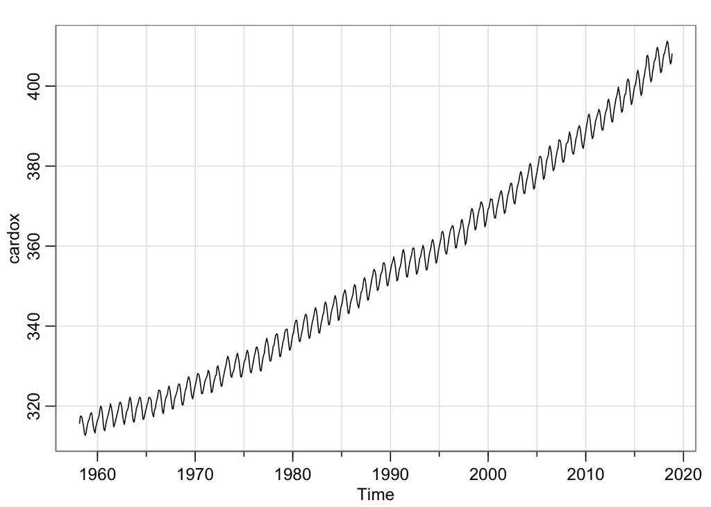

```r
tsplot(cardox)
```

# Seasonal Difference of CARDOX

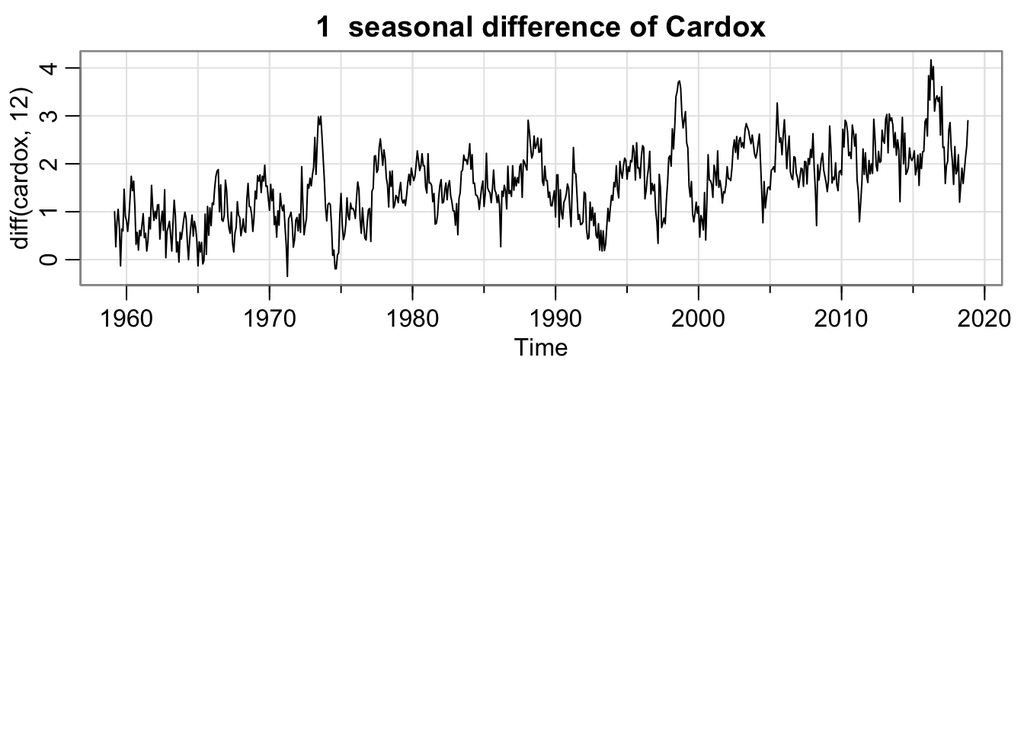

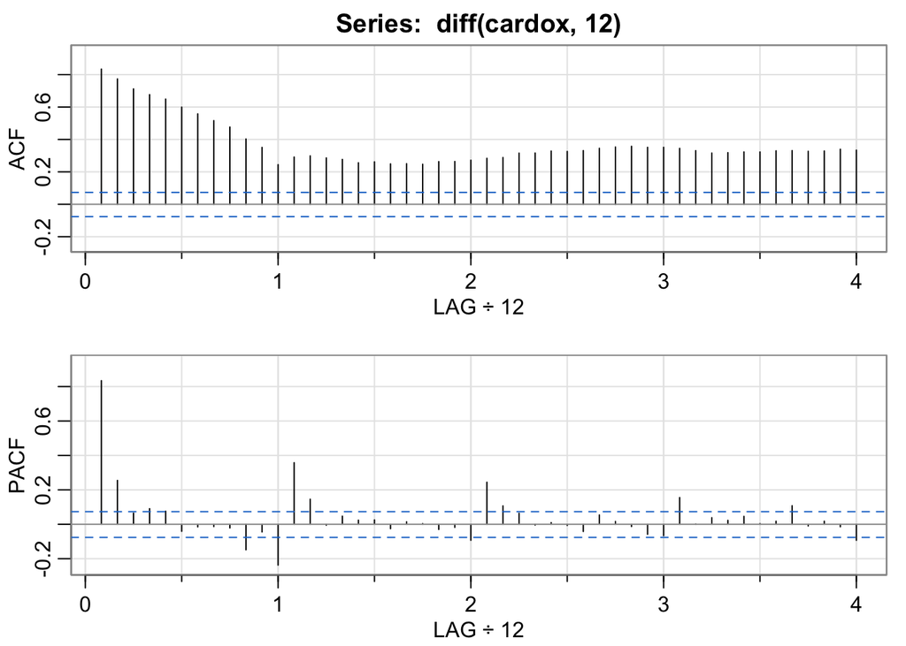

```
##      [,1] [,2] [,3] [,4] [,5]  [,6]  [,7]  [,8]  [,9] [,10] [,11] [,12] [,13]
## ACF  0.83 0.77 0.71 0.68 0.65  0.60  0.56  0.52  0.48  0.40  0.35  0.24  0.29
## PACF 0.83 0.25 0.06 0.09 0.08 -0.04 -0.02 -0.01 -0.02 -0.15 -0.04 -0.24  0.36
##      [,14] [,15] [,16] [,17] [,18] [,19] [,20] [,21] [,22] [,23] [,24] [,25]
## ACF   0.30  0.29  0.28  0.26  0.26  0.25  0.25  0.25  0.26  0.26  0.27  0.28
## PACF  0.15 -0.01  0.05  0.02  0.03 -0.03  0.01  0.00 -0.03 -0.02 -0.09  0.24
##      [,26] [,27] [,28] [,29] [,30] [,31] [,32] [,33] [,34] [,35] [,36] [,37]
## ACF   0.29  0.32  0.32  0.33  0.33  0.33  0.35  0.35  0.36  0.35  0.35  0.35
## PACF  0.11  0.06  0.00  0.01 -0.01 -0.04  0.05  0.02 -0.01 -0.06 -0.07  0.16
##      [,38] [,39] [,40] [,41] [,42] [,43] [,44] [,45] [,46] [,47] [,48]
## ACF   0.33  0.32  0.32  0.32  0.32  0.33  0.33  0.33  0.33  0.34  0.33
## PACF  0.00  0.04  0.02  0.05  0.00  0.02  0.11 -0.01  0.02 -0.01 -0.09
```

```r
par(mfrow=c(2,1))
tsplot(diff(cardox,12), main="1  seasonal difference of Cardox")
acf2(diff(cardox,12))
```

# Simple difference of CARDOX

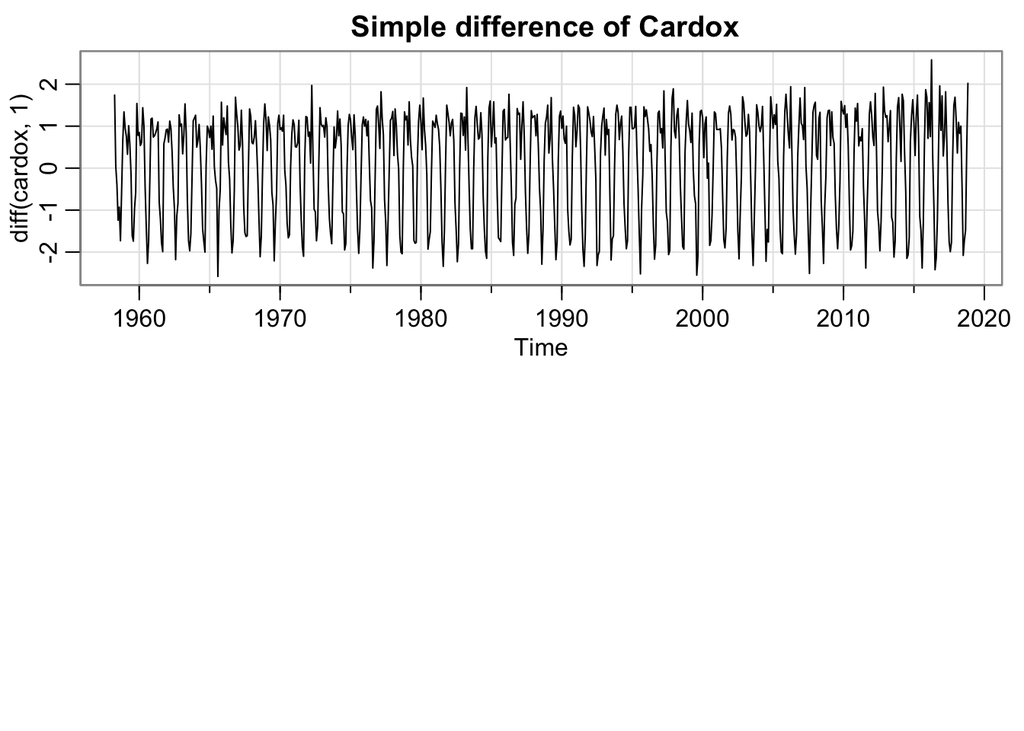

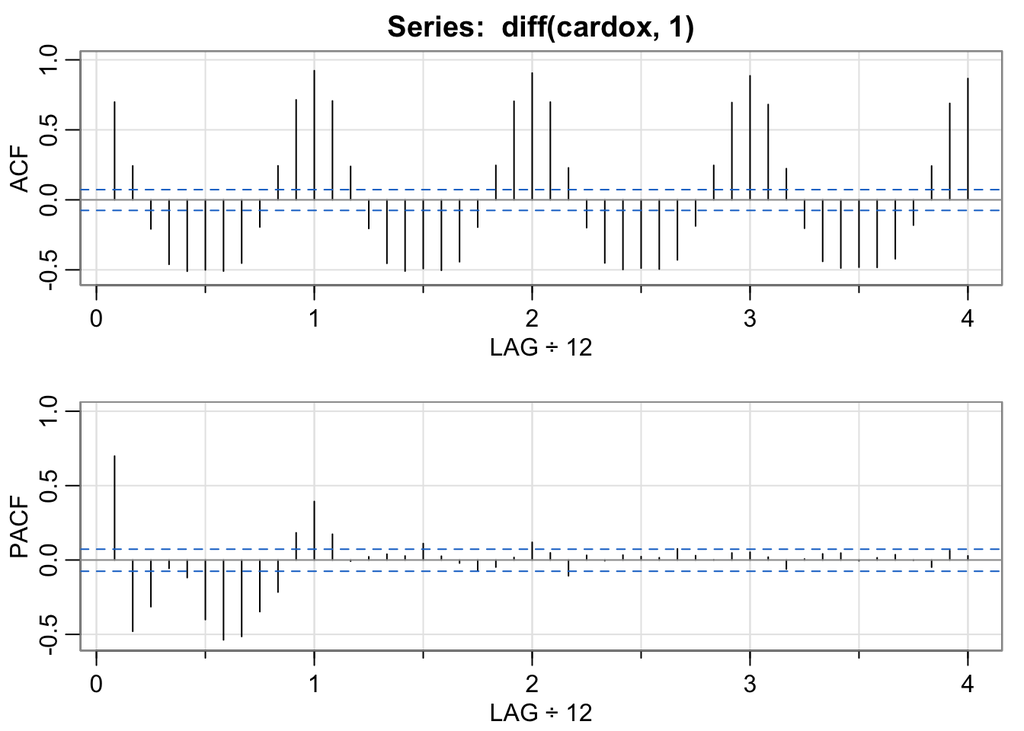

```
##      [,1]  [,2]  [,3]  [,4]  [,5] [,6]  [,7]  [,8]  [,9] [,10] [,11] [,12]
## ACF   0.7  0.24 -0.21 -0.46 -0.51 -0.5 -0.51 -0.45 -0.19  0.24  0.71  0.92
## PACF  0.7 -0.48 -0.31 -0.06 -0.12 -0.4 -0.54 -0.51 -0.35 -0.22  0.18  0.39
##      [,13] [,14] [,15] [,16] [,17] [,18] [,19] [,20] [,21] [,22] [,23] [,24]
## ACF   0.71  0.24 -0.20 -0.45 -0.51 -0.49 -0.50 -0.44 -0.20  0.25  0.70  0.91
## PACF  0.17 -0.01  0.02  0.04  0.03  0.11  0.03 -0.02 -0.07 -0.05  0.02  0.12
##      [,25] [,26] [,27] [,28] [,29] [,30] [,31] [,32] [,33] [,34] [,35] [,36]
## ACF   0.70  0.23 -0.20 -0.45 -0.50 -0.49 -0.49 -0.43 -0.19  0.25  0.69  0.89
## PACF  0.05 -0.11  0.03  0.00  0.03  0.02  0.02  0.08  0.03  0.00  0.05  0.05
##      [,37] [,38] [,39] [,40] [,41] [,42] [,43] [,44] [,45] [,46] [,47] [,48]
## ACF   0.68  0.22 -0.20 -0.44 -0.49 -0.48 -0.48 -0.42 -0.18  0.24  0.69  0.87
## PACF  0.02 -0.06  0.01  0.04  0.05 -0.01  0.02  0.04  0.00 -0.05  0.06  0.03
```

```r
par(mfrow=c(2,1))
tsplot(diff(cardox,1), main =" Simple difference of Cardox")
acf2(diff(cardox,1))
```

# Simple and Seasonal difference of CARDOX

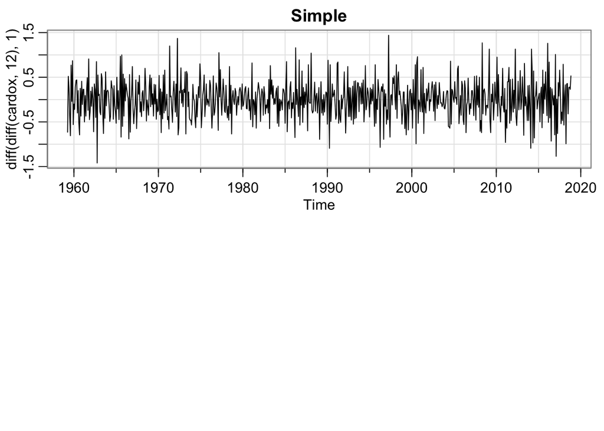

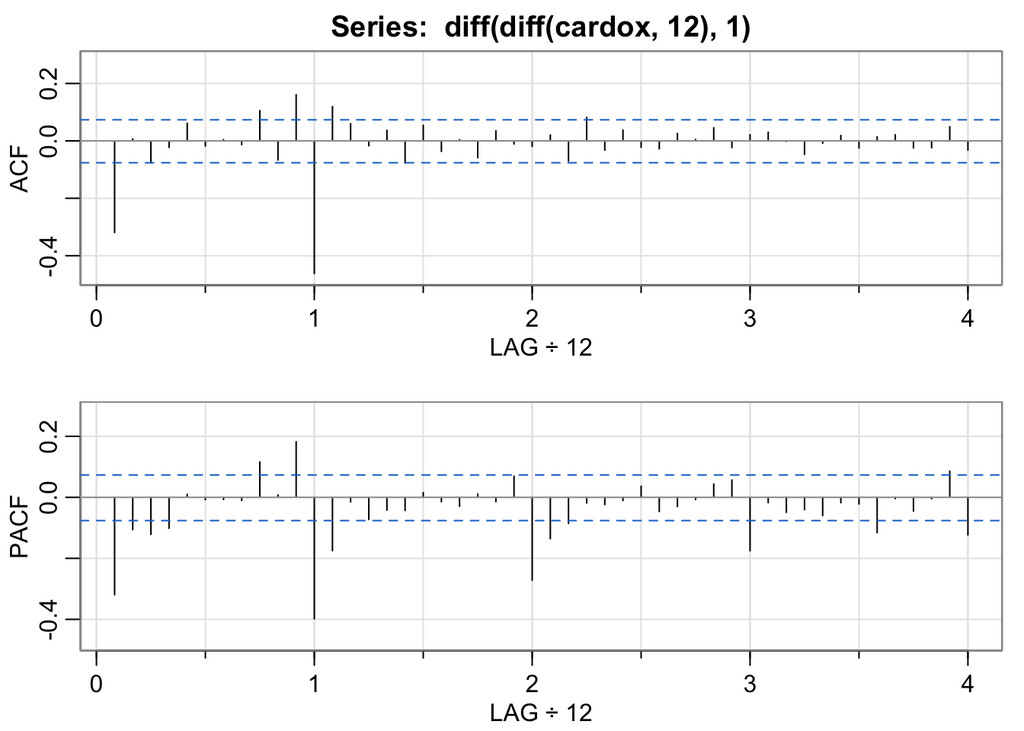

```
##       [,1]  [,2]  [,3]  [,4] [,5]  [,6]  [,7]  [,8] [,9] [,10] [,11] [,12]
## ACF  -0.32  0.01 -0.08 -0.02 0.06 -0.02  0.00 -0.01 0.11 -0.07  0.16 -0.46
## PACF -0.32 -0.11 -0.12 -0.10 0.01 -0.01 -0.01 -0.01 0.12  0.01  0.18 -0.40
##      [,13] [,14] [,15] [,16] [,17] [,18] [,19] [,20] [,21] [,22] [,23] [,24]
## ACF   0.12  0.06 -0.02  0.04 -0.08  0.05 -0.04  0.00 -0.06  0.03 -0.01 -0.02
## PACF -0.17 -0.02 -0.07 -0.04 -0.04  0.02 -0.01 -0.03  0.01 -0.01  0.07 -0.27
##      [,25] [,26] [,27] [,28] [,29] [,30] [,31] [,32] [,33] [,34] [,35] [,36]
## ACF   0.02 -0.07  0.08 -0.03  0.04 -0.02 -0.03  0.03  0.00  0.05 -0.02  0.02
## PACF -0.14 -0.09 -0.02 -0.02 -0.01  0.04 -0.05 -0.03 -0.01  0.04  0.06 -0.18
##      [,37] [,38] [,39] [,40] [,41] [,42] [,43] [,44] [,45] [,46] [,47] [,48]
## ACF   0.03  0.00 -0.05 -0.01  0.02 -0.02  0.01  0.02 -0.02 -0.02  0.05 -0.03
## PACF -0.02 -0.05 -0.04 -0.06 -0.02 -0.02 -0.12  0.00 -0.05  0.00  0.09 -0.12
```

```r
par(mfrow=c(2,1))
tsplot(diff(diff(cardox,12),1), main = " Simple ")
acf2(diff(diff(cardox,12),1))
```

How do we know that we did noi difference neither too much not too little?

- Too many differences will induce a unit root in the MA component
- There are tests called unit root tests, ADF, KPSS are the most well know that helpto decide whetehr to difference or not. The functions ndiffs and nsdiffs indicate the number of differences required, simple and seasonal, respectively.

# A SARIMA Model for CARDOX

```r
cardox_fit1 = sarima(cardox,1,1,1,1,1,1,12)
```

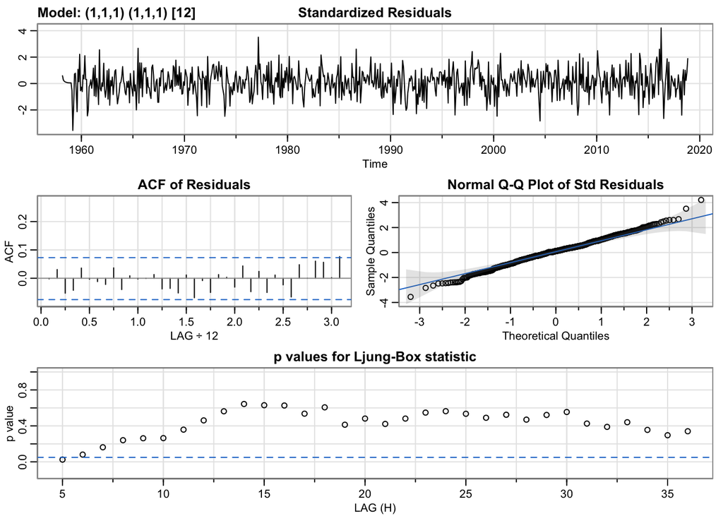

```r
cardox_fit1
```

```
## $fit
##
## Call:
## arima(x = xdata, order = c(p, d, q), seasonal = list(order = c(P, D, Q), period = S),
##     include.mean = !no.constant, transform.pars = trans, fixed = fixed, optim.control = list(trace = trc,
##         REPORT = 1, reltol = tol))
##
## Coefficients:
##          ar1      ma1     sar1     sma1
##       0.1941  -0.5578  -0.0008  -0.8647
## s.e.  0.0953   0.0813   0.0427   0.0211
##
## sigma^2 estimated as 0.09585:  log likelihood = -184.82,  aic = 379.65
##
## $degrees_of_freedom
## [1] 712
##
## $ttable
##      Estimate     SE  t.value p.value
## ar1    0.1941 0.0953   2.0364  0.0421
## ma1   -0.5578 0.0813  -6.8645  0.0000
## sar1  -0.0008 0.0427  -0.0185  0.9852
## sma1  -0.8647 0.0211 -40.9625  0.0000
##
## $AIC
## [1] 0.5302324
##
## $AICc
## [1] 0.530311
##
## $BIC
## [1] 0.5621715
```

Residuals are uncorrelated but the AR coefficient for the seasonal componente is not statistically differente from 0 so we remove it

```r
cardox_fit2=sarima(cardox,1,1,1,0,1,1,12, no.constant = TRUE)
```

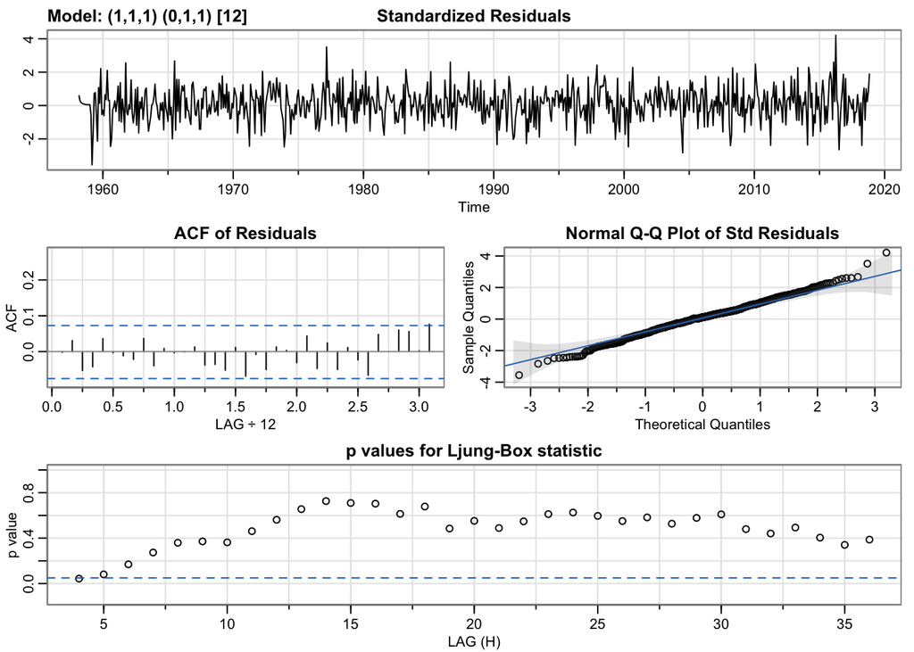

```r
cardox_fit2
```

```
## $fit
##
## Call:
## arima(x = xdata, order = c(p, d, q), seasonal = list(order = c(P, D, Q), period = S),
##     include.mean = !no.constant, transform.pars = trans, fixed = fixed, optim.control = list(trace = trc,
##         REPORT = 1, reltol = tol))
##
## Coefficients:
##          ar1      ma1     sma1
##       0.1941  -0.5578  -0.8648
## s.e.  0.0953   0.0813   0.0189
##
## sigma^2 estimated as 0.09585:  log likelihood = -184.82,  aic = 377.65
##
## $degrees_of_freedom
## [1] 713
##
## $ttable
##      Estimate     SE  t.value p.value
## ar1    0.1941 0.0953   2.0374   0.042
## ma1   -0.5578 0.0813  -6.8634   0.000
## sma1  -0.8648 0.0189 -45.7161   0.000
##
## $AIC
## [1] 0.5274396
##
## $AICc
## [1] 0.5274867
##
## $BIC
## [1] 0.5529909
```

The residuals are still uncorrelated and all the coefficients are significant - a good model

# Identifying over-differencing

Now we take 2 seasonal differences and keep only MA components

```r
cardox_fit3=sarima(cardox,0,1,1,0,2,1,12, no.constant = TRUE)
```

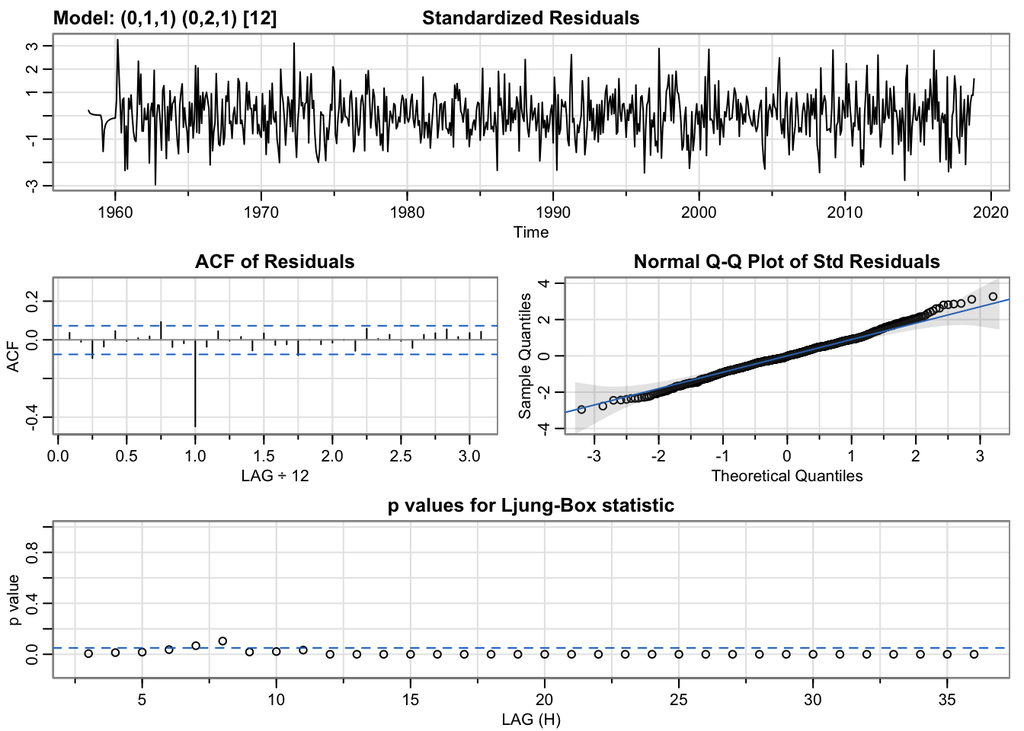

```r
cardox_fit3
```

```
## $fit
##
## Call:
## arima(x = xdata, order = c(p, d, q), seasonal = list(order = c(P, D, Q), period = S),
##     include.mean = !no.constant, transform.pars = trans, fixed = fixed, optim.control = list(trace = trc,
##         REPORT = 1, reltol = tol))
##
## Coefficients:
##           ma1     sma1
##       -0.4008  -0.9992
## s.e.   0.0382   0.0125
##
## sigma^2 estimated as 0.1723:  log likelihood = -408.07,  aic = 822.15
##
## $degrees_of_freedom
## [1] 702
##
## $ttable
##      Estimate     SE  t.value p.value
## ma1   -0.4008 0.0382 -10.4883       0
## sma1  -0.9992 0.0125 -80.0660       0
##
## $AIC
## [1] 1.167823
##
## $AICc
## [1] 1.167847
##
## $BIC
## [1] 1.187241
```

The residuals are no longer uncorrelated and a near unit root appears in the seasonal MA component due to over-differencing.

# Forecasting CARDOX

```r
cardox_train = window(cardox, end=2017+11/12)
cardox_test  =  window(cardox, start=2017+11/12)
cardox_train_fit = sarima(cardox_train,1,1,1,0,1,1,12, no.constant = TRUE)
```

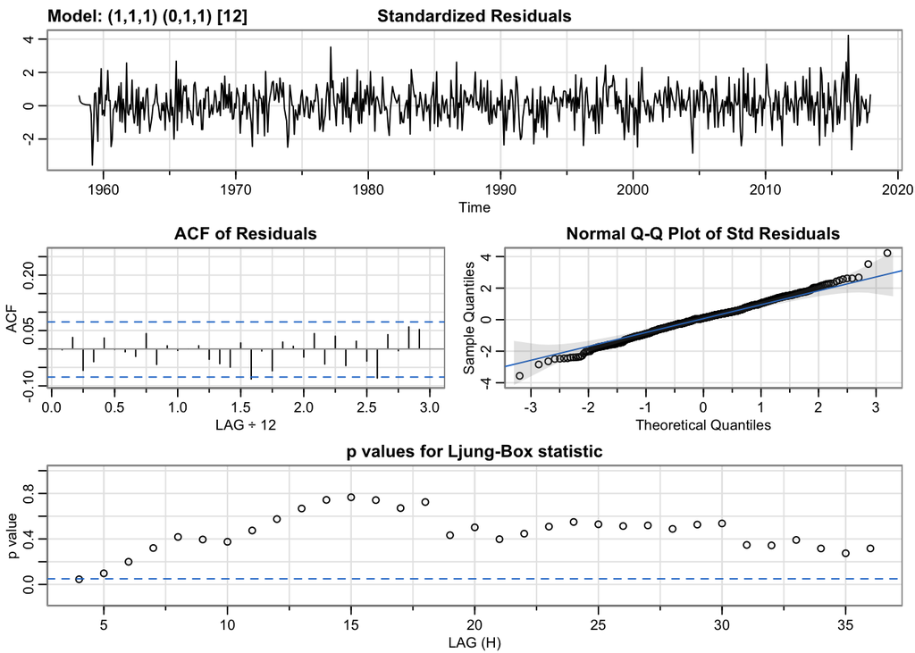

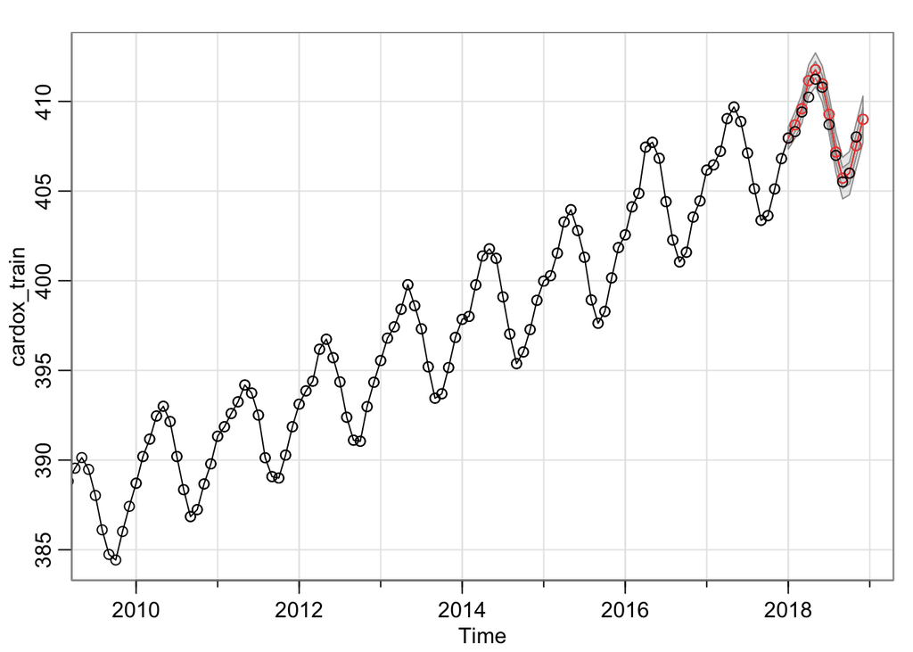

```r
cardox_for = sarima.for(cardox_train,12,1,1,1,0,1,1,12)
points(window(cardox, start=2010))
```

```r
cardox_for$pred
```

```
##           Jan      Feb      Mar      Apr      May      Jun      Jul      Aug
## 2018 407.9543 408.6884 409.5939 411.1594 411.7648 410.9800 409.2828 407.1763
##           Sep      Oct      Nov      Dec
## 2018 405.7225 405.9961 407.5363 409.0011
```

```r
cardox_for$se
```

```
##            Jan       Feb       Mar       Apr       May       Jun       Jul
## 2018 0.3088345 0.3661362 0.4054179 0.4394436 0.4706895 0.4999244 0.5275300
##            Aug       Sep       Oct       Nov       Dec
## 2018 0.5537587 0.5787997 0.6028013 0.6258831 0.6481435
```

```r
accuracy(cardox_for$pred, cardox_test)
```

```
##                 ME      RMSE       MAE         MPE       MAPE      ACF1
## Test set -0.242259 0.4230058 0.3319427 -0.05914122 0.08112234 0.1892028
##          Theil's U
## Test set 0.3395784
```

```r
accuracy(cardox_for$pred, cardox_test)
```

```
##                 ME      RMSE       MAE         MPE       MAPE      ACF1
## Test set -0.242259 0.4230058 0.3319427 -0.05914122 0.08112234 0.1892028
##          Theil's U
## Test set 0.3395784
```